# EE550HW4

Erhan Can Ozcan

4/18/2019

# Winner Take-all Network

In this project, we will cluster points located on the surface of a 3D-sphere with radius 1. Points are clustered in 3 region, and each cluster has 30 points. In other words, there are 90 points in total. The first cluster(c1) of points have (-,+,+) cordinates, the second cluster(c2) of points have (+,+,+) coordinates. Lastly, the third cluster(c3) of points have (-,-,-). All points are genereated from chisquare distribution, after producing the points, signs are adjusted as explained above. Then, data points are normalized by dividing them to their lengths.

You can see the plot of whole points in the below.

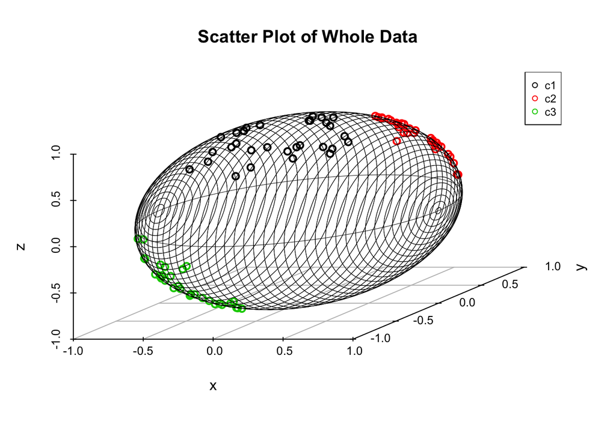

3 unit weight vectors in 3-D are formed by using a normal distribution. You can see the initial weights and whole data points in the plot below.

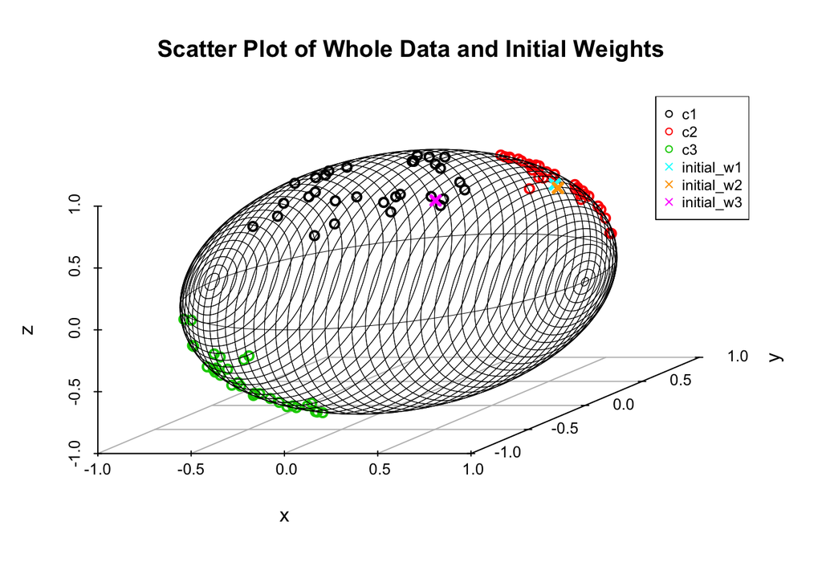

27 data points from each cluster, 81 data points are selected as training set. These points are utilized to train a winner take-all network. The weights of winner unit updated for each sample. After each epoch, cost function given in the class is calculated, when the value of this cost function becomes less than a threshold learning stops. Threshold is selected as 10.6. During learning, I observed a fluctuation in the value of cost function. To solve this problem, I decided to update the value of step length according to the following rule $n=n*0.95^{epochcounter}$. As a result of this, n becomes smaller after each iteration.

All data points in training set are used 11 times during the training(After 11 epochs learning stops). The plot below shows the clusters and the movement of weight vectors during the training. Location of weights are shown after each epoch because it becomes too complicated when they are plotted after each update.

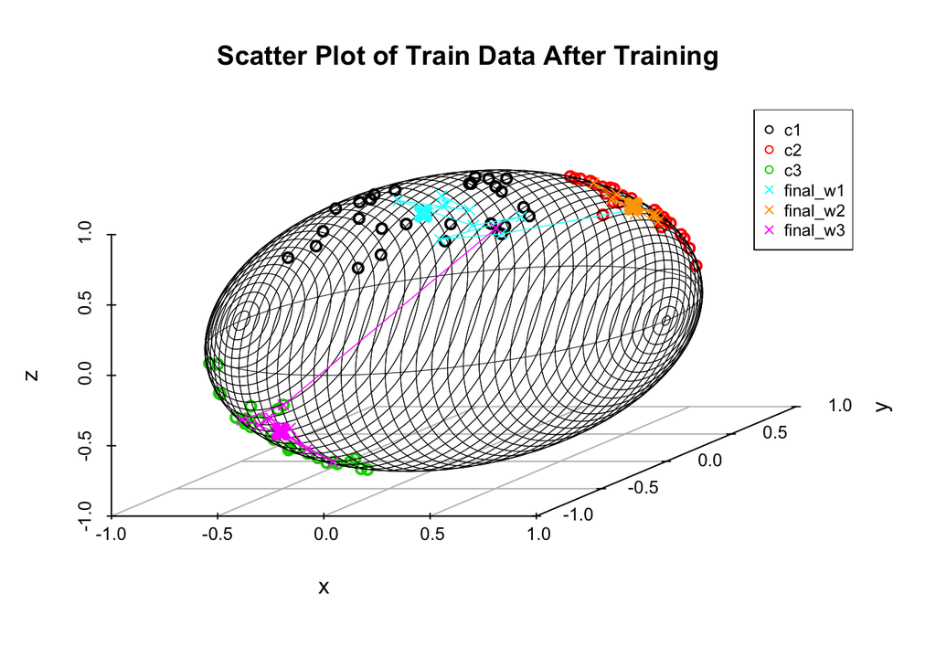

From the plot below, you can monitor how the total cost function changes after each epoch until learning stops.

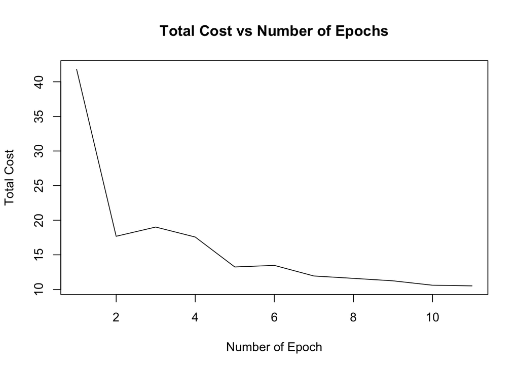

### Test

After training, 9 points are tested through using the obtained weight vectors. Before clustering these new points, the locations of data points and weights can be seen below.

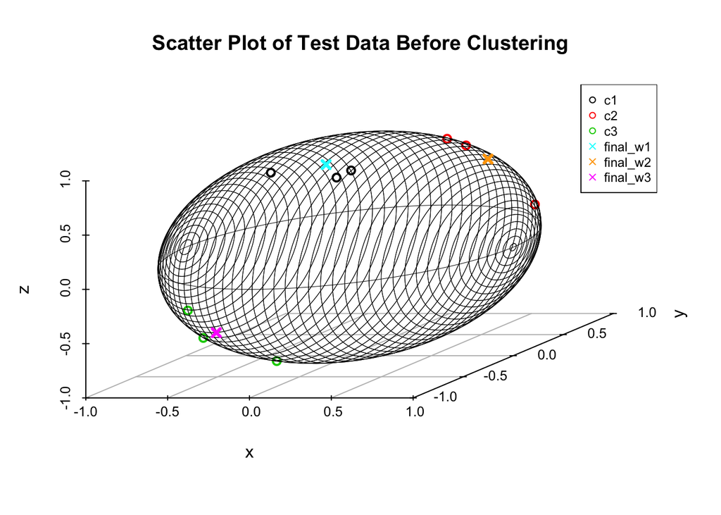

#### Initial Clusters of test data

```r
(test_input_initial_clusters=all_clusters_test[,4])
```

```
## [1] 2 2 2 3 3 3 1 1 1
```

Through using the learned weights, these new points are assigned to the existing clusters. Note that each column is a new sample in the matrix(A matrix let’s say) below. $A_{ij}$: value of output unit i for sample j. Also, you can see the clusters which test samples are assigned to.

```r
test_input=all_clusters_test[,-4]
h_i_pred=W%*%t(test_input)
(round(h_i_pred,3))
```

```
##        [,1]   [,2]   [,3]   [,4]   [,5]   [,6]   [,7]   [,8]   [,9]
## [1,]  0.114  0.503  0.407 -0.397 -0.673  0.006  0.886  0.892  0.885
## [2,]  0.809  0.911  0.936 -0.959 -0.855 -0.874  0.307  0.394  0.139
## [3,] -0.783 -0.879 -0.901  0.926  0.829  0.833 -0.318 -0.401 -0.152
```

```r
(max_values=apply(h_i_pred,2,which.max))
```

```
## [1] 2 2 2 3 3 3 1 1 1
```

As it can be seen from the plot below, all points are clustered correctly.

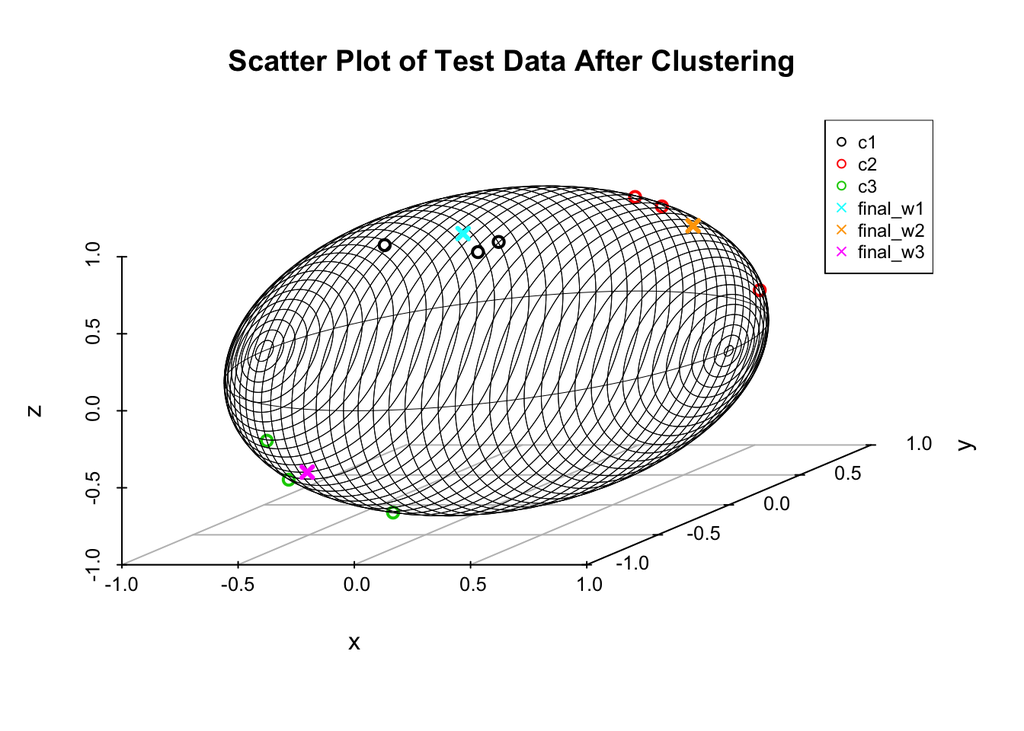

```r
#library(rgl)
library(scatterplot3d)
library(data.table)

#construct data 100 sample 50A 50B in 3-D----
set.seed(1)

calculate_length<-function(x){
  return(sqrt(sum(x^2)))
}
n=1
no_tr_data=81
no_teest_data=9
no_input=3
no_cluster=3
#obtain training data
clus1_tr<-matrix(rchisq(81,8),nrow=27,ncol=3)
length<-apply(clus1_tr,1,calculate_length)
clus1_tr=clus1_tr/length
#clus1_tr[27,]/sqrt(sum(clus1_tr[27,]^2))
clus1_tr<-cbind(clus1_tr,2)

clus2_tr<-matrix(-rchisq(81,8),nrow=27,ncol=3)
length<-apply(clus2_tr,1,calculate_length)
clus2_tr=clus2_tr/length
clus2_tr<-cbind(clus2_tr,3)

clus3_tr<-matrix(rchisq(81,8),nrow=27,ncol=3)
clus3_tr[,1]<-clus3_tr[,1]*-1
length<-apply(clus3_tr,1,calculate_length)
clus3_tr=clus3_tr/length
clus3_tr<-cbind(clus3_tr,1)

all_clusters_training<-rbind(clus1_tr,clus2_tr)
all_clusters_training<-rbind(all_clusters_training,clus3_tr)

#obtain_test_data
clus1_test<-matrix(rchisq(9,8),nrow=3,ncol=3)
length<-apply(clus1_test,1,calculate_length)
clus1_test=clus1_test/length
clus1_test<-cbind(clus1_test,2)

clus2_test<-matrix(-rchisq(9,8),nrow=3,ncol=3)
length<-apply(clus2_test,1,calculate_length)
clus2_test=clus2_test/length
clus2_test<-cbind(clus2_test,3)

clus3_test<-matrix(rchisq(9,8),nrow=3,ncol=3)
clus3_test[,1]<-clus3_test[,1]*-1
length<-apply(clus3_test,1,calculate_length)
clus3_test=clus3_test/length
clus3_test<-cbind(clus3_test,1)

all_clusters_test<-rbind(clus1_test,clus2_test)
all_clusters_test<-rbind(all_clusters_test,clus3_test)

whole_data<-rbind(all_clusters_training,all_clusters_test)


s3d<-scatterplot3d(whole_data[,1:3],color=(whole_data[,4]),angle=35,grid=TRUE,box=FALSE,main="Scatter Plot of Whole Data",xlab="x",ylab="y",zlab="z",pch=1,lwd=2)

a=seq(-pi,pi, length=100)
x=c(rep(1, 100) %*% t(cos(a)))
y=c(cos(a) %*% t(sin(a)))
z=c(sin(a) %*% t(sin(a)))
s3d$points3d(x, y,z, type="l", col="black", lwd=0.5)
legend("topright",legend=c("c1","c2","c3"),col=c(2,3,1),cex=0.75,pch=1)
##

##learning
#initialize unit weights.
W<-matrix(rnorm(9,2,4),nrow=no_cluster)
length<-apply(W,1,calculate_length)
W=W/length

#Construct weight lists
W_list<-list(W)


train_input=all_clusters_training[,-4]
no_epoch=100
cum_error<-vector()
ep=1
decide_to_continue=TRUE
#for(ep in 1:no_epoch){
while(decide_to_continue==TRUE){
  cum_error[ep]=0
  assigned_to_which_clus<-NULL
  sample_order=sample(no_tr_data)
  for(counter in 1:no_tr_data){
    sample_index=sample_order[counter]
    inst=matrix((train_input[sample_index,]),ncol=no_input)
    h_i_matrix=W%*%t(inst)
    i_star=which(h_i_matrix==max(h_i_matrix))
    assigned_to_which_clus<-c(assigned_to_which_clus,i_star)
    update=n*(inst-W[i_star,])
    W[i_star,]=W[i_star,]+update
    #W_list[[length(W_list)+1]]<-W
  }
  #calculate total error at the end of epoch
  for(counter in 1:no_tr_data){
    sample_index=sample_order[counter]
    inst=matrix((train_input[sample_index,]),ncol=no_input)
    error=(W[assigned_to_which_clus[counter],]-inst)%*%t(W[assigned_to_which_clus[counter],]-inst)
    cum_error[ep]=cum_error[ep]+error
  }
  n=n*(0.95)^ep
  W_list[[length(W_list)+1]]<-W
  if(cum_error[length(cum_error)]<10.6){
    decide_to_continue=FALSE
  }
  ep=ep+1
}
cum_error

h_i_matrix=W%*%t(train_input)
max_values_train=apply(h_i_matrix,2,which.max)
s3d<-scatterplot3d(train_input[,1:3],color=(max_values_train),angle=35,grid=TRUE,box=FALSE,main="Scatter Plot of Train Data After Training",xlab="x",ylab="y",zlab="z",pch=1,lwd=2,xlim = c(-1,1),ylim = c(-1,1),zlim = c(-1,1))
a=seq(-pi,pi, length=100)
x=c(rep(1, 100) %*% t(cos(a)))
y=c(cos(a) %*% t(sin(a)))
z=c(sin(a) %*% t(sin(a)))
s3d$points3d(x, y,z, type="l", col="black", lwd=0.5)

xx1<-NULL
yy1<-NULL
zz1<-NULL

xx2<-NULL
yy2<-NULL
zz2<-NULL

xx3<-NULL
yy3<-NULL
zz3<-NULL

for(it in 1:length(W_list)){

    xx1<-c(xx1,W_list[[it]][1,1])
    yy1<-c(yy1,W_list[[it]][1,2])
    zz1<-c(zz1,W_list[[it]][1,3])
    xx2<-c(xx2,W_list[[it]][2,1])
    yy2<-c(yy2,W_list[[it]][2,2])
    zz2<-c(zz2,W_list[[it]][2,3])
    xx3<-c(xx3,W_list[[it]][3,1])
    yy3<-c(yy3,W_list[[it]][3,2])
    zz3<-c(zz3,W_list[[it]][3,3])
    #s3d$points3d(W_list[[it]][cl_cntr,1], W_list[[it]][cl_cntr,2],W_list[[it]][cl_cntr,3], type="p", col="yellow", lwd=0.5,pch=4)

}
s3d$points3d(x=xx1, y=yy1,z=zz1, type="l", col="cyan", lwd=0.75)
s3d$points3d(x=xx1, y=yy1,z=zz1, type="p", col="cyan", lwd=1,pch=4)
s3d$points3d(x=xx1[length(xx1)], y=yy1[length(yy1)],z=zz1[length(zz1)], type="p", col="cyan", lwd=6,pch=4)


s3d$points3d(x=xx2, y=yy2,z=zz2, type="l", col="orange", lwd=0.75)
s3d$points3d(x=xx2, y=yy2,z=zz2, type="p", col="orange", lwd=1,pch=4)
s3d$points3d(x=xx2[length(xx2)], y=yy2[length(yy2)],z=zz2[length(zz2)], type="p", col="orange", lwd=6,pch=4)

s3d$points3d(x=xx3, y=yy3,z=zz3, type="l", col="magenta", lwd=0.75)
s3d$points3d(x=xx3, y=yy3,z=zz3, type="p", col="magenta", lwd=1,pch=4)
s3d$points3d(x=xx3[length(xx3)], y=yy3[length(yy3)],z=zz3[length(zz3)], type="p", col="magenta", lwd=6,pch=4)

plot(cum_error,main = "Total Cost vs Number of Epochs", xlab="Number of Epoch", ylab = "Total Cost",type="l")

#test
#plot only test data
s3d<-scatterplot3d(all_clusters_test[,1:3],color=(all_clusters_test[,4]),angle=35,grid=TRUE,box=FALSE,main="Scatter Plot of Test Data Before Training",xlab="x",ylab="y",zlab="z",pch=1,lwd=2,xlim = c(-1,1),ylim = c(-1,1),zlim = c(-1,1))

a=seq(-pi,pi, length=100)
x=c(rep(1, 100) %*% t(cos(a)))
y=c(cos(a) %*% t(sin(a)))
z=c(sin(a) %*% t(sin(a)))
s3d$points3d(x, y,z, type="l", col="black", lwd=0.5)

test_input=all_clusters_test[,-4]
h_i_pred=W%*%t(test_input)
max_values=apply(h_i_pred,2,which.max)
s3d<-scatterplot3d(test_input[,1:3],color=(max_values),angle=35,grid=TRUE,box=FALSE,main="Scatter Plot of Test Data After Training",xlab="x",ylab="y",zlab="z",pch=1,lwd=2,xlim = c(-1,1),ylim = c(-1,1),zlim = c(-1,1))
a=seq(-pi,pi, length=100)
x=c(rep(1, 100) %*% t(cos(a)))
y=c(cos(a) %*% t(sin(a)))
z=c(sin(a) %*% t(sin(a)))
s3d$points3d(x, y,z, type="l", col="black", lwd=0.5)

s3d$points3d(x=xx1[length(xx1)], y=yy1[length(yy1)],z=zz1[length(zz1)], type="p", col="cyan", lwd=3,pch=4)
s3d$points3d(x=xx2[length(xx2)], y=yy2[length(yy2)],z=zz2[length(zz2)], type="p", col="orange", lwd=3,pch=4)
s3d$points3d(x=xx3[length(xx3)], y=yy3[length(yy3)],z=zz3[length(zz3)], type="p", col="magenta", lwd=3,pch=4)

h_i_pred
max_values
```